# Shark Control Program Catch Statistics

Group 4 Project 2

Student(s) SID: 480431929, 480474498, 490413195

University of Sydney | MATH1005 | November 2019

# 1 Executive Summary

## 1.1 Initial Data Analysis 1

The data is sourced from the QLD Government’s Department of Agriculture and Fisheries which aims to, through strategic industrial development, maximise the economic potential for Queensland’s primary industries as well as provide information on agricultural, fishery and forestry sectors. As this is a government organisation, any data that is produced is valid and can be used for research and analysis. This data was collected as part of the Queensland Shark Control Program (SCP) which aims to reduce the threat of shark attacks through the use of nets and drumlines. Limitations of this data may include researcher bias towards certain times of the year, e.g. poor weather conditions or tropical cyclones in certain months limit access to drum lines and nets. The dataset has 532 observations with 10 variables. Each row represents a single shark catch while columns represent information relating to the catch such as date of capture, location and size. For the purposes of this report, only tiger shark captures were examined with accordance to catch location and month of capture. Possible stakeholders for this data are the general public who swim and surf in Queensland beaches, marine researchers and fishing companies, as well as environmental groups.

According to the Department of Agriculture and Fisheries in Queensland, shark catch statistics are gathered using shark control equipment such as nets and drumlines. Rather than creating an impenetrable barrier against shark attacks, the SCP instead aims to decrease potentially dangerous sharks in particular areas and does so by using large mesh nets that are designed to catch sharks over 2m in length. This equipment is supposedly installed far enough offshore to prevent human and shark interaction which makes catch statistics more reliable as chances of unwanted tampering are reduced. The Department states that SCP equipment is serviced every second day and removed at least once every 21 days to be replaced with fresh equipment. This shows that great care and consistency is shown meaning that catches are quite accurate and rarely ever missed. Limitations of the data origin include limited resources which lead to only certain locations being targeted for catches. This may bias the data and make it unrepresentative of actual shark populations. The SCP has attempted to trial the use of SMART drumlines in other areas of Australia to further move sharks offshore so as to decrease interactions between swimmers and other water users. However, in many of Queensland’s northern waters, offshore areas are still used thoroughly which then prevents drumlines from being effective. The frequent use of offshore areas in the north may also account for greater catch numbers and shark control equipment being used. This then skews data that is collected as there is evidently more equipment in a certain area, which in turn, leads to more catches.

```r
str(sharks)
```

```
## Classes 'spec_tbl_df', 'tbl_df', 'tbl' and 'data.frame': 532 obs. of  10 variables:
##  $ Species Name  : chr  "AUSTRALIAN BLACKTIP" "BLACKTIP REEF WHALER" "BLACKTIP REEF WHALER" "BLACKTIP REEF WHALER" ...
##  $ Date          : POSIXct, format: "2016-11-16" "2016-01-02" ...
##  $ Area          : chr  "Cairns" "Cairns" "Cairns" "Mackay" ...
##  $ Location      : chr  "Holloways Beach" "Buchans Point Beach" "Ellis Beach" "Harbour Beach" ...
##  $ Latitude      : chr  "-16°49.82" "-16°43.56" "-16°43.3" "-21°7.08" ...
##  $ Longitude     : chr  "145°44.85" "145°39.78" "145°39.01" "149°13.62" ...
##  $ Length (m)    : num  1 0.7 1.5 2.2 1.7 1.2 0.75 1.2 0.8 1.3 ...
##  $ Water Temp (C): num  27 27 27 26 26 29 30 31 29 29 ...
##  $ Month         : chr  "November" "January" "January" "January" ...
##  $ Day of Week   : chr  "Wednesday" "Saturday" "Saturday" "Tuesday" ...
##  - attr(*, "spec")=
##   .. cols(
##   ..   `Species Name` = col_character(),
##   ..   Date = col_datetime(format = ""),
##   ..   Area = col_character(),
##   ..   Location = col_character(),
##   ..   Latitude = col_character(),
##   ..   Longitude = col_character(),
##   ..   `Length (m)` = col_double(),
##   ..   `Water Temp (C)` = col_double(),
##   ..   Month = col_character(),
##   ..   `Day of Week` = col_character()
##   .. )
```

## 1.2 Are tiger shark numbers at different locations in 2016 different in when compared to the mean number of tiger sharks in each area from 1993 to 2010.

Prior data has shown a significant downward trend in tiger shark numbers at some locations (Cairns, Gladstone, Bundaberg and Gold Coast). In others, this downward trend was not significant (Townsville, Capricorn Coast, Sunshine Coast, North Stradbroke Is.), and significantly increased in Mackay (Holmes et al., 2012).

We compared the yearly tiger shark catch means of each location in 2016 to the mean of 1993-2010 to examine whether tiger shark catch numbers were higher or lower than the previously examined period. Due to the six year gap between the data, large differences may be indicative of a trend in catch numbers (which in turn has been assumed to reflect total population numbers), though analysis of more data would be required to quantify this.

Figure 1 shows the 1993-2010 mean compared to the 2016 mean at each location. All had a decrease in tiger shark catch numbers, with the exception of Townsville (note, Rainbow Beach is excluded here as past data was not seen as reliable in Holmes et al., 2012).

We then tested whether the difference in the total number of tiger sharks caught in 2016 in Qld and the 2001-2010 mean was significant.

Figure 1:

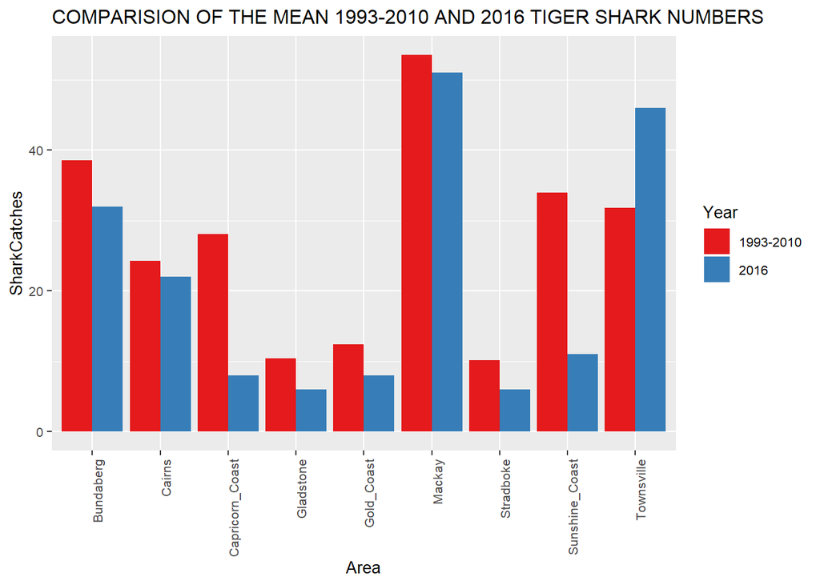

```r
counts = table(sharks$`Species Name`[317:523], sharks$Area[317:523])
#counts is just used to see the desired data in a table form and plot it in our own order and format

library(ggplot2)
data <- read.table(
  header = TRUE,  text = 'Year                Area SharkCatches
1  1993-2010          Cairns      24.28
2       2016          Cairns         22
3  1993-2010      Townsville      31.77
4       2016      Townsville         46
5  1993-2010          Mackay      53.55
6       2016          Mackay         51
7  1993-2010 Capricorn_Coast      28.12
8       2016 Capricorn_Coast          8
9  1993-2010       Gladstone      10.39
10      2016       Gladstone          6
11 1993-2010       Bundaberg      38.55
12      2016       Bundaberg         32
13 1993-2010  Sunshine_Coast         34
14      2016  Sunshine_Coast         11
15 1993-2010       Stradboke      10.17
16      2016       Stradboke          6
17 1993-2010      Gold_Coast      12.38
18      2016      Gold_Coast          8')


ggplot(data, aes(Area, SharkCatches, fill = Year)) + geom_bar(stat="identity", position = "dodge") + scale_fill_brewer(palette = "Set1") + theme(text = element_text(size=10), axis.text.x = element_text(angle=90, hjust=1)) + ggtitle("COMPARISION OF THE MEAN 1993-2010 AND 2016 TIGER SHARK NUMBERS")
```

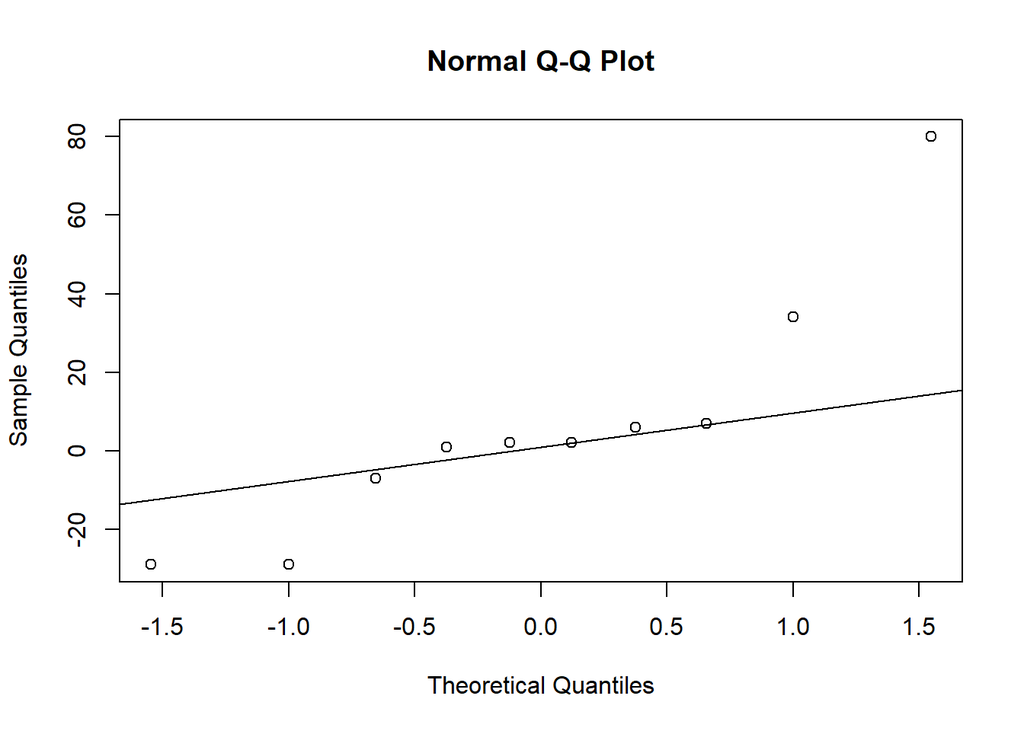

```r
x = 207
box = c(287, 214, 178, 200, 241, 209, 209, 208, 213, 178)
diff = box - x

qqnorm(diff)
qqline(diff)
```

```r
shapiro.test(diff)
```

```
##
##  Shapiro-Wilk normality test
##
## data:  diff
## W = 0.84496, p-value = 0.05058
```

```r
wilcox.test(mu=0, diff, alternative = "greater", exact = F)
```

```
##
##  Wilcoxon signed rank test with continuity correction
##
## data:  diff
## V = 34.5, p-value = 0.2534
## alternative hypothesis: true location is greater than 0
```

Here, we see that the p-value is 0.2534, which means that we should retain the null hypothesis as there is insufficient evidence to reject it.

Further research into this downward trend should focus on more recent data. Although drum lines and nets have been relatively consistent (Holmes et al., 2012), minor changes may affect the sharks caught. Similarly, natural disasters such as tropical cyclones, disrupt the collection of data in a way which would amplify the variance between years. As tiger sharks are listed as an endangered species, however (see Holmes et al., 2012), we should be cautious in applying this finding without further data analysis.

## 1.3 Is there a seasonal trend to tiger shark catch numbers in different regions?

Holmes et la. (2012) found that tiger shark catch rates from 1993-2010 “were highest during the cooler months (Apr-Aug) in northern Qld, and during the warmer months (Oct-Feb) in southern Qld” (pg 40).

We questioned whether we could determine tiger shark catch rates of warmer months in southern sites higher than those in cooler months in 2016? And is the inverse true for northern sites? We can observe that there is a seasonal difference, see Figure 2 and 3.

Note, we defined North and South as per Holmes et al. (2012). North: Cairns, Townsville, Mackay, Capricorn Coast, Gladstone, Bundaberg. South: Rainbow Beach, Sunshine Coast, North Stradbroke Is., Gold Coast.

Figure 2:

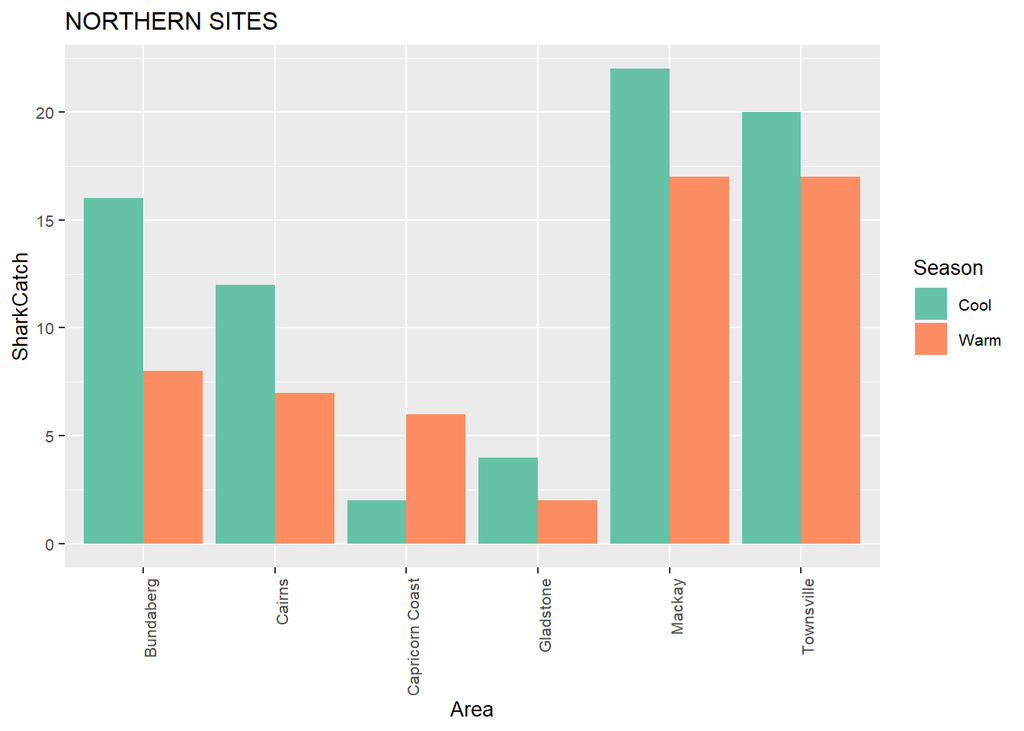

```r
#Northern Region
counts = table(sharks$`Species Name`[317:523], sharks$Area[317:523], sharks$Month[317:523])
#counts is just used to see the desired data in a table form and plot it in our own order and format

Season = c("Warm", "Cool", "Warm", "Cool", "Warm", "Cool", "Warm", "Cool", "Warm", "Cool", "Warm", "Cool")
Area = c("Cairns", "Cairns", "Townsville", "Townsville", "Mackay", "Mackay", "Capricorn Coast", "Capricorn Coast", "Gladstone", "Gladstone", "Bundaberg", "Bundaberg")
SharkCatch = c(7, 12, 17, 20, 17, 22, 6, 2, 2, 4, 8, 16)
data <- data.frame(Season, Area, SharkCatch)

ggplot(data, aes(Area, SharkCatch, fill = Season)) + geom_bar(stat="identity", position = "dodge") + scale_fill_brewer(palette = "Set2") + theme(text = element_text(size=10), axis.text.x = element_text(angle=90, hjust=1)) + ggtitle("NORTHERN SITES")
```

Figure 3:

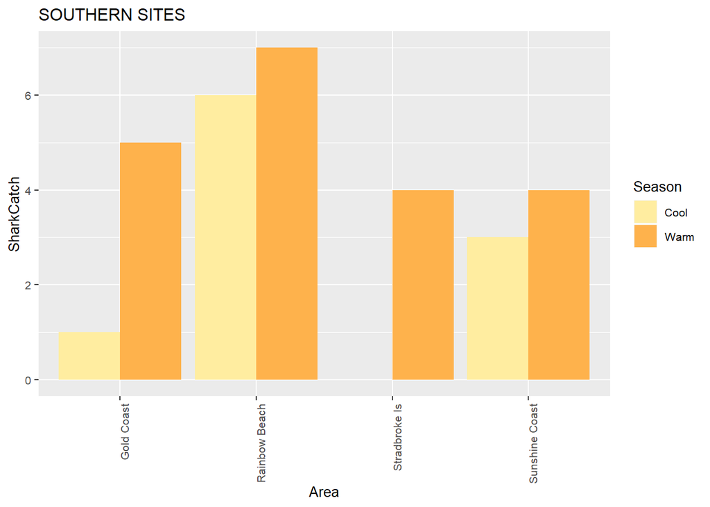

```r
#Southern Region
counts = table(sharks$`Species Name`[317:523], sharks$Area[317:523], sharks$Month[317:523])
#counts is just used to see the desired data in a table form and plot it in our own order and format

Season = c("Warm", "Cool", "Warm", "Cool", "Warm", "Cool", "Warm", "Cool")
Area = c("Rainbow Beach", "Rainbow Beach", "Sunshine Coast", "Sunshine Coast", "Stradbroke Is", "Stradbroke Is", "Gold Coast", "Gold Coast")
SharkCatch = c(7, 6, 4, 3, 4, 0, 5, 1)
data <- data.frame(Season, Area, SharkCatch)

ggplot(data, aes(Area, SharkCatch, fill = Season)) + geom_bar(stat="identity", position = "dodge") + scale_fill_brewer(palette = "YlOrRd") + theme(text = element_text(size=10), axis.text.x = element_text(angle=90, hjust=1)) + ggtitle("SOUTHERN SITES")
```

However, our aim was to test whether there was a significant difference in the overall number of tiger shark catches between seasons. We therefore tested the following hypothesis.

North

H0: there is no significant difference between catches in warm and cool months.

H1: there were significantly more catches in cool months than warm.

South

H0: there was no significant difference between catches in warm and cool months.

TESTING NORMALITY (Northern Region)

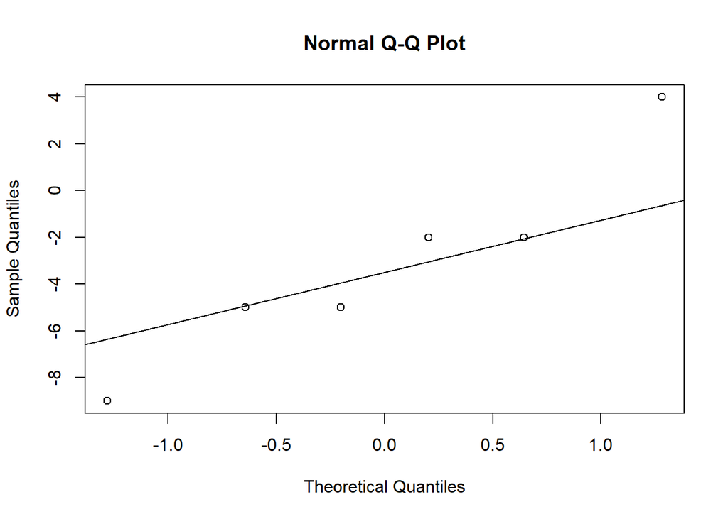

```r
NWarm = c(7, 7, 6, 2, 17, 18)
NCool = c(16, 12, 2, 4, 22, 20)
Ndiff = NWarm - NCool

qqnorm(Ndiff)
qqline(Ndiff)
```

```r
shapiro.test(Ndiff)
```

```
##
##  Shapiro-Wilk normality test
##
## data:  Ndiff
## W = 0.94477, p-value = 0.6979
```

T Test assuming its normal (Northern Region)

```r
t.test(mu=0, Ndiff, alternative = "less")
```

```
##
##  One Sample t-test
##
## data:  Ndiff
## t = -1.7811, df = 5, p-value = 0.0675
## alternative hypothesis: true mean is less than 0
## 95 percent confidence interval:
##       -Inf 0.4159914
## sample estimates:
## mean of x
## -3.166667
```

TESTING NORMALITY (Southern Region)

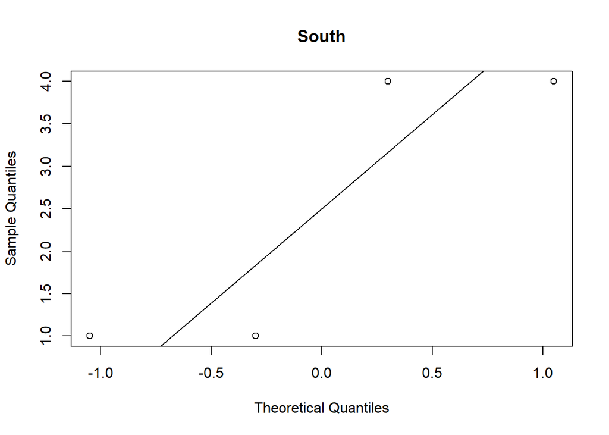

```r
SWarm = c(7, 4, 4, 5)
SCool = c(6, 3, 0, 1)
Sdiff = SWarm - SCool

qqnorm(Sdiff, main = "South")
qqline(Sdiff)
```

```r
shapiro.test(Sdiff)
```

```
##
##  Shapiro-Wilk normality test
##
## data:  Sdiff
## W = 0.72863, p-value = 0.02386
```

Wilcox Test not assuming normality (Southern Region)

```r
wilcox.test(mu=0, Sdiff, alternative = "greater", exact = FALSE)
```

```
##
##  Wilcoxon signed rank test with continuity correction
##
## data:  Sdiff
## V = 10, p-value = 0.04734
## alternative hypothesis: true location is greater than 0
```

The difference in tiger shark catches between the warm and cool months in northern locations was not significant, p = 0.0675. Consequently, we retain H0.

However, we found that warmer months in southern locations had significantly more catches than cooler months, p = 0.04734 (note, Wilcoxon function used in southern hypothesis testing as the distribution was found to not be normal with the Q-Q plots and Shapiro-Wilk normality test, unlike the data related to North. This is likely due to smaller sample size here). Hence, we reject H0.

Our finding here contributes to the understanding that there is a seasonal trend to tiger shark populations in southern Qld. This may be attributed to the migratory nature of tiger sharks. Tiger sharks are a solitary species and are found in tropical and subtropical waters globally, and NSW and southern Qld are at the southern end of their natural range (Holmes et al., 2012; Holmes, Pepperell, Griffiths, Jaine, Tibbetts, & Bennett, 2014). They do not migrate universally as a species, and do so on individual levels, and it has been shown that water temperature and prey are potential reasons for migration (Holmes et al., 2012, Holmes et. al., 2014). As water temperature drops too far in cooler months, this prompts more sharks to migrate to warmer waters; on Australia’s east coast, this means north, or east and further off-shore (Holmes et al., 2014). Consequently, we observe a significant difference in shark numbers in southern Qld between warm and cool seasons.

We could suggest then that the seasonal catch difference in northern Qld was not significant as these migratory influences are not as pronounced as southern Qld, however, more research is required to qualify this.

# 2 References:-

1. Holmes, B., Sumpton, W., Mayer, D., Tibbetts, I., Neil, D., & Bennett, M. (2012). Declining trends in annual catch rates of the tiger shark (Galeocerdo cuvier) in Queensland, Australia. Fisheries Research, 129–130, 38–45.
2. Holmes, B. J., Pepperell, J. G., Griffiths, S. P., Jaine, F. R., Tibbetts, I. R., & Bennett, M. B. (2014). Tiger shark (Galeocerdo cuvier) movement patterns and habitat use determined by satellite tagging in eastern Australian waters. Marine biology, 161(11), 2645-2658.